# Debiased Machine Learning Guide

## Introduction

Causal inference is an important task in economics. In a complex world with many factors for economists to consider, it is extremely valuable to know what actually causes economic phenomena. However, this is a difficult task in economics because it is often impossible or infeasible to actually run an experiment, making discerning a causal impact difficult. Economists have come up with many methods to attempt to solve this problem. One emerging method that was recently discovered is called debiased machine learning. This method leverages the effectiveness of machine learning in prediction tasks to accurately calculate causal parameters.

The basic problem of causal inference is to find, when all other factors are held constant, what is the average treatment effect across a population. We are essentially interested in comparing two nearly identical worlds, that differ only in that in one world some treatment is applied, and in the other world the treatment is not applied. One way we might approach this is to try to model the world. Using a sophisticated machine learning model, it is possible to predict an outcome variable given a large number of input variables. If we believe that this model accurately captures how the world works, then we can find a causal treatment effect by comparing two inputs where everything is held constant except for the treatment variable. One such model could be the conditional expectation function $\gamma_0(D_i=t,X) = \mathbb{E}[Y|D_i=t,X]$. Let our data consist of inputs $W_i = (D_i,X_i)$. Then, we can use the equation

$\hat{\theta} = 1/n\sum_{i=1}^{n} m(W_i,\hat{\gamma})$ where $m(W_i,\hat{\gamma}) = \hat{\gamma}(D_i = 1, X_i)-\hat{\gamma}(D_i = 0, X_i)$ to estimate $\hat{\theta}$. However, this approach suffers from bias and doesn't return an accurate estimate for $\theta$. This is where debiased machine learning comes in. Debiased machine learning adjusts the results above to remove bias using the following equation:

$$\hat{\theta} = \frac{1}{n}\sum_{l=1}^{L}\sum_{i \in I_l} m(W_i,\hat{\gamma}_l)+\hat{\alpha}_l(W_i)(Y_i-\hat{\gamma}_l(X_i))$$

where $\alpha$ is a learned parameter called the riesz representer (discussed in appendix C). Using this insight into how to remove bias, we can then calculate causal parameters using debiased machine learning. The algorithm for debiased machine learning is as follows:

1. Split the dataset into L subsets $I_1,..I_L$.
2. Learn $\alpha_l$ and $\gamma_l$ from elements outside of $I_l$.
3. Calculate $\hat{\theta}$ using learned $\alpha_l$ and $\gamma_l$ on elements they haven't been trained on in $I_l$ and averaging over all i. This process is captured in the following equation:
   $$\hat{\theta} = \frac{1}{n}\sum_{l=1}^{L}\sum_{i \in I_l} m(W_i,\hat{\gamma}_l)+\hat{\alpha}_l(W_i)(Y_i-\hat{\gamma}_l(X_i))$$

This guide will walk through R code for the aforementioned debiased machine learning algorithm. The example used looks at the impact of access to a 401k on lifetime savings. This guide has two goals:

1. Help the reader understand the technical details of the debiased machine learning algorithm
2. Provide a framework the reader can use to implement debiased machine learning with their own data and specifications

The text above each paragraph will provide an overview of what the code below does. Details about specifics of the code will be explained in comments in the code. The appendix will walk through how to adapt the code for use with your own data.

This guide will focus very little on the math behind debiased machine learning. If the reader is interested in this, there will be some discussion in the appendix, but the best source is the original paper on debiased machine learning at https://arxiv.org/abs/1608.00060.

## Setting Initial Parameters/Loading Packages

Below are the necessary packages and basic functions. Short descriptions are available above each of the functions. For the code to work, change the working directory at the end of this code block to the directory with the downloaded 401k data (or directory with your data if you are using your own dataset).

```r
rm(list=ls())

###########
#Libraries#
###########

library("foreign")
library("dplyr")
```

```r
library("ggplot2")
library("quantreg") #used for rq.fit.sfn
library("nnet") #used for mulitnom
library("randomForest")
#################
#Basic Functions#
#################

#Euclidean Norm
two.norm <- function(x){
  return(sqrt(x %*% x))
}

#dictionary that converts d and z to vector with intercept term
#used to calculate alpha and gamma
b<-function(d,z){
  return(c(1,d,z))
}

#dictionary that converts d and z to vector with intercept term and interaction term
#used to calculate alpha and gamma
b2<-function(d,z){
  return(c(1,d,z,d*z))
}

#m function mentioned in the introduction
m<-function(y,d,z,gamma){ #all data arguments to make interchangeable with m2
  return(gamma(1,z)-gamma(0,z))
}
#used to calculate matrix N, which is used to calculate gamma_hat and perform regression
m2<-function(y,d,z,gamma){
  return(y*gamma(d,z))
}
#psi_tilde for debiased machine learning (actual parameter, debiased moment function)
psi_tilde<-function(y,d,z,m,alpha,gamma){
  return(m(y,d,z,gamma)+alpha(d,z)*(y-gamma(d,z)))
}
#psi_tilde with a bias. Used to demonstrate shortfall of not accounting for bias. Won't achieve actual debiased machine learning
psi_tilde_bias<-function(y,d,z,m,alpha,gamma){
  return(m(y,d,z,gamma))
}
#Gets M,N and G matrices. These are necessary for calculating the riesz representer, which is discussed in appendix C, and also calculating gamma. Outputs will have dimensions: M (p x 1), N (p x 1), G (p x p)
get_MNG<-function(Y,T,X,b){

  p=length(b(T[1],X[1,]))
  n.nl=length(T)

  B=matrix(0,n.nl,p)
  M=matrix(0,p,n.nl)
  N=matrix(0,p,n.nl)
  #Takes average by collecting into a matrix and averaging the rows
  for (i in 1:n.nl){
    B[i,]=b(T[i],X[i,])
    M[,i]=m(Y[i],T[i],X[i,],b)
    N[,i]=m2(Y[i],T[i],X[i,],b)
  }

  M_hat=rowMeans(M)
  N_hat=rowMeans(N)
  G_hat=t(B)%*%B/n.nl

  return(list(M_hat,N_hat,G_hat,B))
}

setwd("~/Documents/research/rrr_tutorial")
```

## Preparing Data

The following "get_data" function will prepare the data for debiased machine learning. This code splits the data into three components:

1. Y := vector of the outcome variable
2. T := vector of the treatment variable
3. X := matrix with confounding variables

```r
get_data<-function(df,spec,quintile){
  ###  Inputs
  ###  df: dataset that is being used. In this case a .dta but could be another format
  ###  spec: value of 1,2,or 3.
  ###  quintile: integer in [0,5]. 0 means all data, 1-5 indicates which quintile of income distribution to filter for
  ###  Output
  ###  List of (Y,D,X)
  Y <- df[,"net_tfa"]
  D <- df[,"e401"]
  #  All three specifications incorporate the same variables, but differ in the number of higher order terms. X.L has no higher order terms. X.H has higher order terms up to the 8th degree for some variables. X.vH incorporates higher order and interaction terms.
  ## low dim specification
  X.L <- cbind(df[,"age"], df[,"inc"], df[,"educ"], df[,"fsize"], df[,"marr"], df[,"twoearn"], df[,"db"], df[,"pira"], df[,"hown"])

  ## high dim specification.
  X.H <- cbind(poly(df[,"age"], 6, raw=TRUE),
               poly(df[,"inc"], 8, raw=TRUE),
               poly(df[,"educ"], 4, raw=TRUE),
               poly(df[,"fsize"], 2, raw=TRUE),
               df[,"marr"], df[,"twoearn"], df[,"db"], df[,"pira"], df[,"hown"])

  ## very high dim specification
  X.vH=model.matrix(~(poly(df[,"age"], 6, raw=TRUE) +
                        poly(df[,"inc"], 8, raw=TRUE) +
                        poly(df[,"educ"], 4, raw=TRUE) +
                        poly(df[,"fsize"], 2, raw=TRUE) +
                        df[,"marr"] +
                        df[,"twoearn"] +
                        df[,"db"] +
                        df[,"pira"] +
                        df[,"hown"])^2)
  X.vH=X.vH[,-1]

  #Selects for desires specification
  if (spec==1){
    X=X.L
  } else if (spec==2) {
    X=X.H
  } else {
    X=X.vH
  }

  X <- scale(X,center=TRUE,scale=TRUE) #Centers and scales X
  n=nrow(X)
  #Impose common support. More discussion in Appendix B.
  p.1 <- multinom(D~X-1, trace=FALSE)$fitted.values
  indexes.to.drop <- which(p.1 < min(p.1[D==1]) | max(p.1[D==1]) < p.1)
  if (length(indexes.to.drop)==0) {indexes.to.drop <- n+1}  #R throws a wobbly if [-indexes.to.drop] is negating an empty set.
  n.per.treatment <- as.vector(table(D[-indexes.to.drop]))
  n.trim <- n.per.treatment[1]+n.per.treatment[2]

  Y.trimmed=Y[-indexes.to.drop]
  D.trimmed=D[-indexes.to.drop]
  X.trimmed=X[-indexes.to.drop,]

  if (spec==1){
    inc=X.trimmed[,2]
  } else if (spec==2) {
    inc=X.trimmed[,7]
  } else {
    inc=X.trimmed[,7]
  }
  #Filters for desired quintile
  if (quintile>0){
    q <- ntile(inc, 5)
    Y.q=Y.trimmed[q==quintile]
    D.q=D.trimmed[q==quintile]
    X.q=X.trimmed[q==quintile,]
  } else {
    Y.q=Y.trimmed
    D.q=D.trimmed
    X.q=X.trimmed
  }

  return(list(Y.q,D.q,X.q))

}
```

## Learning Alpha and Gamma

Once the data is in the correct form, we can begin stage one of this algorithm. This involves estimating $\alpha$ and $\gamma$ using machine learning. This code sets up various machine learning models that can be applied here. In the following code, "RMD_dantzig" and "RMD_lasso" implement dantzig and lasso learning models respectively. Then, "RMD_stable" implements the algorithm to find $\hat{\rho}$, the coefficient of $\hat{\alpha}$, and $\hat{\beta}$, the coeffecient of $\hat{\gamma}$. Understanding "RMD_dantzig", "RMD_lasso", and "get_D" in depth is not essential to understanding this code. These are essentially helper functions that assist in tuning parameters in our learned models.

```r
l=0.1

#Dantzig learning algorithm to tune regularization parameter
RMD_dantzig <- function(M, G, D, lambda=0, sparse = TRUE) {

  p <- ncol(G)
  zp <- rep(0, p)
  L <-c(l,rep(1,p-1)) #dictionary is ordered (constant,T,X,TX)

  A <- solve(diag(D),G)
  R <- rbind(A, -A)

  a <- solve(diag(D),M)
  r <- c(a - lambda*L, -a - lambda*L)

  if(sparse) {
    Ip <- as(p, "matrix.diag.csr")
    R <- as.matrix.csr(R)
    f <- rq.fit.sfnc(Ip, zp, R = R, r = r)
  } else {
    Ip <- diag(p)
    f <- rq.fit.fnc(Ip, zp, R = R, r = r)
  }

  return(f)
}
#Lasso learning algorithm to tune the regularization paremeter of our model
RMD_lasso <- function(M, G, D, lambda=0, control = list(maxIter = 1000, optTol = 10^(-5),
                                                        zeroThreshold = 10^(-6)), beta.start = NULL) {

  p <- ncol(G)

  Gt<-G
  Mt<-M

  L <-c(l,rep(1,p-1)) #dictionary is ordered (constant,...)
  lambda_vec=lambda*L*D #v3: insert D here

  if (is.null(beta.start)) {
    beta <- rep(0,p) #vs low-dimensional initialization
  }
  else {
    beta <- beta.start
  }
  wp <- beta
  mm <- 1
  while (mm < control$maxIter) {
    beta_old <- beta
    for (j in 1:p) {
      rho=Mt[j]-Gt[j,]%*%beta+Gt[j,j]*beta[j]
      z=Gt[j,j]

      if (sum(is.na(rho)) >= 1) {
        beta[j] <- 0
        next
      }
      if (rho < -1 * lambda_vec[j])
        beta[j] <- (rho+lambda_vec[j])/z
      if (abs(rho) <= lambda_vec[j])
        beta[j] <- 0
      if (rho > lambda_vec[j])
        beta[j] <- (rho-lambda_vec[j])/z
    }
    wp <- cbind(wp, beta)
    if (sum(abs(beta - beta_old), na.rm = TRUE) < control$optTol) {
      break
    }
    mm <- mm + 1
  }
  w <- beta
  w[abs(w) < control$zeroThreshold] <- 0
  return(list(coefficients = w, coef.list = wp, num.it = mm))
}

#Performs theoretical iteration to help tune our regularization parameter
get_D <- function(Y,T,X,m,rho_hat,b){
  n=nrow(X)
  p=length(b(T[1],X[1,]))

  df=matrix(0,p,n)
  for (i in 1:n){
    df[,i]=b(T[i],X[i,])*as.vector(rho_hat %*% b(T[i],X[i,]))-m(Y[i],T[i],X[i,],b)
  }
  df=df^2
  D2=rowMeans(df)

  D=sqrt(D2)
  return(D) #pass around D as vector
}

c=0.5
alpha=0.1
tol=1e-6
#Calculates ML function for alpha and gamma
RMD_stable<-function(Y,T,X,p0,D_LB,D_add,max_iter,b,is_alpha = TRUE,is_lasso = TRUE){
  ###Inputs
  ###Y,T,X: data
  ###p0: initial parameter for p
  ###D_LB: Lower bound on D
  ###D_add: value added to D
  ###max_iter: maximum iterations of chosen ML algorithm
  ###b: dictionary
  ###is_alpha: True = return alpha, False = return gamma
  ###is_lasso: True = use lasso, False = use dantzig
  ###Output
  ###rho_hat or beta_hat, a vector to estimate alpha or gamma rescpectively by taking the dot product with b
  k=1

  p=length(b(T[1],X[1,]))
  n=length(T)

  # low-dimensional moments
  X0=X[,1:p0]
  MNG0<-get_MNG(Y,T,X0,b)
  M_hat0=MNG0[[1]]
  N_hat0=MNG0[[2]]
  G_hat0=MNG0[[3]]

  # initial estimate
  rho_hat0=solve(G_hat0,M_hat0)
  rho_hat=c(rho_hat0,rep(0,p-ncol(G_hat0)))
  beta_hat0=solve(G_hat0,N_hat0)
  beta_hat=c(beta_hat0,rep(0,p-ncol(G_hat0)))

  # moments
  MNG<-get_MNG(Y,T,X,b)
  M_hat=MNG[[1]]
  N_hat=MNG[[2]]
  G_hat=MNG[[3]]

  # penalty
  lambda=c*qnorm(1-alpha/(2*p))/sqrt(n) # snippet

  if(is_alpha){
    ###########
    # alpha_hat
    ###########
    diff_rho=1
    #Loop through max_iter times or until the change in rho between iterations is less than tol
    while(diff_rho>tol & k<=max_iter){

      # previous values
      rho_hat_old=rho_hat+0

      # normalization
      D_hat_rho=get_D(Y,T,X,m,rho_hat_old,b)
      D_hat_rho=pmax(D_LB,D_hat_rho)
      D_hat_rho=D_hat_rho+D_add

      # RMD estimate
      if(is_lasso){
        rho_hat=RMD_lasso(M_hat, G_hat, D_hat_rho, lambda)$coefficients
      }else{
        rho_hat=RMD_dantzig(M_hat, G_hat, D_hat_rho, lambda)$coefficients
      }

      # difference
      diff_rho=two.norm(rho_hat-rho_hat_old)
      k=k+1


    }

    print(paste0('k: '))
    print(paste0(k))
    return(rho_hat)

  } else {
    ###########
    # gamma_hat
    ###########
    diff_beta=1
     #Loop through max_iter times or until the change in rho between iterations is less than tol
    while(diff_beta>tol & k<=max_iter){

      # previous values
      beta_hat_old=beta_hat+0

      # normalization
      D_hat_beta=get_D(Y,T,X,m2,beta_hat_old,b)
      D_hat_beta=pmax(D_LB,D_hat_beta)
      D_hat_beta=D_hat_beta+D_add

      # RMD estimate
      if(is_lasso){
        beta_hat=RMD_lasso(N_hat, G_hat, D_hat_beta, lambda)$coefficients
      }else{
        beta_hat=RMD_dantzig(N_hat, G_hat, D_hat_beta, lambda)$coefficients
      }

      # difference
      diff_beta=two.norm(beta_hat-beta_hat_old)
      k=k+1

    }

    print(paste0('k: '))
    print(paste0(k))
    return(beta_hat)

  }
}

arg_Forest<- list(clas_nodesize=1, reg_nodesize=5, ntree=1000, na.action=na.omit, replace=TRUE)
arg_Nnet<- list(size=8,  maxit=1000, decay=0.01, MaxNWts=10000,  trace=FALSE)
```

Using the above functions, "get_stage1" returns $\alpha$ and $\gamma$ estimators for an outcome variable (Y), treatment variable (T) and confounding variables (X). The basic process for finding either $\alpha$ or $\gamma$ is to calculate the vector $\hat{\rho}$ or $\hat{\beta}$ respectively and then return a function that is the dot product of this vector with the chosen dictionary b that maps W in some way.

```r
get_stage1<-function(Y,T,X,p0,D_LB,D_add,max_iter,b,alpha_estimator = 1,gamma_estimator = 1){
  ###Inputs
  ###Y,T,X: data
  ###p0: initial parameter for p
  ###D_LB: Lower bound on D
  ###D_add: value added to D
  ###max_iter: maximum iterations of chosen ML algorithm
  ###b: dictionary
  ###alpha_estimator: numerical value indicating which model to use for the alpha estimator
  ###0 dantzig, 1 lasso
  ###gamma_estimator: numerical value indicating which model to use for the gamma estimator
  ###0 dantzig, 1 lasso, 2 rf, 3 nn
  ###Output
  ###alpha_hat and gamma_hat estimators

  p=length(b(T[1],X[1,]))
  n=length(T)
  MNG<-get_MNG(Y,T,X,b)
  B=MNG[[4]]

  ###########
  # alpha hat
  ###########
  if(alpha_estimator==0){ # dantzig

    rho_hat=RMD_stable(Y,T,X,p0,D_LB,D_add,max_iter,b,1,0)
    alpha_hat<-function(d,z){
      return(b(d,z)%*%rho_hat)
    }

  } else if(alpha_estimator==1){ # lasso

    rho_hat=RMD_stable(Y,T,X,p0,D_LB,D_add,max_iter,b,1,1)
    alpha_hat<-function(d,z){
      return(b(d,z)%*%rho_hat)
    }

  }

  ###########
  # gamma hat
  ###########
  if(gamma_estimator==0){ # dantzig

    beta_hat=RMD_stable(Y,T,X,p0,D_LB,D_add,max_iter,b,0,0)
    gamma_hat<-function(d,z){
      return(b(d,z)%*%beta_hat)
    }

  } else if(gamma_estimator==1){ # lasso

    beta_hat=RMD_stable(Y,T,X,p0,D_LB,D_add,max_iter,b,0,1)
    gamma_hat<-function(d,z){
      return(b(d,z)%*%beta_hat)
    }

  } else if(gamma_estimator==2){ # random forest

    forest<- do.call(randomForest, append(list(x=B,y=Y), arg_Forest))
    gamma_hat<-function(d,z){
      return(predict(forest,newdata=b(d,z), type="response"))
    }

  } else if(gamma_estimator==3){ # neural net

    # scale down, de-mean, run NN, scale up, remean so that NN works well
    maxs_B <- apply(B, 2, max)
    mins_B <- apply(B, 2, min)

    maxs_Y<-max(Y)
    mins_Y<-min(Y)

    # hack to ensure that constant covariates do not become NA in the scaling
    const=maxs_B==mins_B
    keep=(1-const)*1:length(const)

    NN_B<-B
    NN_B[,keep]<-scale(NN_B[,keep], center = mins_B[keep], scale = maxs_B[keep] - mins_B[keep])

    NN_Y<-scale(Y, center = mins_Y, scale = maxs_Y - mins_Y)

    nn<- do.call(nnet, append(list(x=NN_B,y=NN_Y), arg_Nnet))
    gamma_hat<-function(d,z){

      test<-t(as.vector(b2(d,z)))
      NN_b<-test
      NN_b[,keep]<-scale(t(NN_b[,keep]),
                         center = mins_B[keep],
                         scale = maxs_B[keep] - mins_B[keep])

      NN_Y_hat<-predict(nn,newdata=NN_b)
      Y_hat=NN_Y_hat*(maxs_Y-mins_Y)+mins_Y

      return(Y_hat)
    }

  }

  return(list(alpha_hat,gamma_hat))

}
```

## Running DML

The final step of this algorithm is to use the learned alpha and gamma estimators to estimate the parameter of interest. At this point we have functions set up that are able to learn the $\alpha$ and $\gamma$ functions. The "rrr" function starts by splitting up our data into subsets so that we can learn $\alpha$ and $\gamma$. It then learns $\alpha_i$ and $\gamma_i$ for all i and finds $\hat{\theta}$ and the standard error of $\hat{\theta}$.

```r
L=5 #parameter for number of subsets to split data into

rrr<-function(Y,T,X,p0,D_LB,D_add,max_iter,dict,alpha_estimator,gamma_estimator,bias){

  n=nrow(X)
  #Split up into I_1,...I_n
  folds <- split(sample(n, n,replace=FALSE), as.factor(1:L))

  Psi_tilde=numeric(0) #Initialize Psi_tilde as 0. This will become a running list of
  #Iterating through I_1,,,,I_n
  for (l in 1:L){
    #Breaks into two sets. variables with .l are not in X_i used for training. variables with .nl are used for calculating theta
    Y.l=Y[folds[[l]]]
    Y.nl=Y[-folds[[l]]]

    T.l=T[folds[[l]]]
    T.nl=T[-folds[[l]]]

    X.l=X[folds[[l]],]
    X.nl=X[-folds[[l]],]

    n.l=length(T.l)
    n.nl=length(T.nl)

    # get stage 1 (on nl)
    stage1_estimators<-get_stage1(Y.nl,T.nl,X.nl,p0,D_LB,D_add,max_iter,dict,alpha_estimator,gamma_estimator)
    alpha_hat=stage1_estimators[[1]]
    gamma_hat=stage1_estimators[[2]]

    print(paste0('fold: ',l))

    #get stage 2 (on l)
    #psi_star
    Psi_tilde.l=rep(0,n.l)
    for (i in 1:n.l){
      if(bias){ #plug-in
        Psi_tilde.l[i]=psi_tilde_bias(Y.l[i],T.l[i],X.l[i,],m,alpha_hat,gamma_hat) # without subtracting theta_hat
      }else{ #DML
        Psi_tilde.l[i]=psi_tilde(Y.l[i],T.l[i],X.l[i,],m,alpha_hat,gamma_hat) # without subtracting theta_hat
      }
    }

    Psi_tilde=c(Psi_tilde,Psi_tilde.l)


  }

  #point estimation
  ate=mean(Psi_tilde)

  #influences
  Psi=Psi_tilde-ate

  var=mean(Psi^2)
  se=sqrt(var/n)
  #Returns ATE and SE
  out<-c(table(T)[[2]],table(T)[[1]],ate,se)

  return(out)
}
#Prints out the results of rrr in a way that is easy to read
printer<-function(spec1){
  print(paste(" treated: ",spec1[1], " untreated: ", spec1[2], "   ATE:    ",round(spec1[3],2), "   SE:   ", round(spec1[4],2), sep=""))
}
#Prints results of rrr in format suitable for LaTex
for_tex<-function(spec1){
  print(paste(" & ",spec1[1], " & ", spec1[2], "   &    ",round(spec1[3],2), "   &   ", round(spec1[4],2), sep=""))
}
```

```r
for (quintile in 0:0){ #change "0:5" to "0:0" if you just want to run once on whole data set

quintile=0 #comment out this line to iterate through quintiles

  print(paste0('quintile: '))
  print(paste0(quintile))

df  <- read.dta("sipp1991.dta")
#df = read.csv("Voting.csv")

spec=1 #spec in (1-3)
#quintile=0 #quintile in (1-5). 0 means all quintiles
data<-get_data(df,spec,quintile) #trimming like Farrell; different than Chernozhukov et al.

Y=data[[1]]
T=data[[2]]
X=data[[3]] #no intercept

##################
# helper functions
##################


# dictionary for calculating alpha (discussion in appendix C)
dict=b # b for partially linear model, b2 for interacted model. note that b2 appears in stage1.R for NN
p=length(b(T[1],X[1,]))


#p0=dim(X0) used in low-dim dictionary in the stage 1 tuning procedure
p0=ceiling(p/4)
if (p>60){
  p0=ceiling(p/40)

}


D_LB=0 #each diagonal entry of \hat{D} lower bounded by D_LB
D_add=.2 #each diagonal entry of \hat{D} increased by D_add. 0.1 for 0, 0,.2 otw
max_iter=10 #max number iterations in Dantzig selector iteration over estimation and weights

###########
# algorithm
###########

set.seed(1) # for sample splitting

alpha_estimator=1
gamma_estimator=1
bias=0
#alpha_estimator: 0 dantzig, 1 lasso
#gamma_estimator: 0 dantzig, 1 lasso, 2 rf, 3 nn

results<-rrr(Y,T,X,p0,D_LB,D_add,max_iter,dict,alpha_estimator,gamma_estimator,bias)
printer(results)
for_tex(results)

}
```

```
## [1] "quintile: "
## [1] "0"
```

```
## [1] "k: "
## [1] "6"
## [1] "k: "
## [1] "8"
## [1] "fold: 1"
## [1] "k: "
## [1] "6"
## [1] "k: "
## [1] "8"
## [1] "fold: 2"
## [1] "k: "
## [1] "6"
## [1] "k: "
## [1] "8"
## [1] "fold: 3"
## [1] "k: "
## [1] "6"
## [1] "k: "
## [1] "8"
## [1] "fold: 4"
## [1] "k: "
## [1] "6"
## [1] "k: "
## [1] "8"
## [1] "fold: 5"
## [1] " treated: 3682 untreated: 6166   ATE:    5813.95   SE:   1485.55"
## [1] " & 3682 & 6166   &    5813.95   &   1485.55"
```

## Appendix A: Using Other Data

The above framework is very flexible and can be easily adapted to fit other data sets. To do so, it requires adjusting "get_data" to return Y,T, and X as a list, where Y and T are vectors and X is a matrix (It is important to note that you can't have any NA values in X,Y or T). The following steps outline this process:

```r
#df = df%>%
#  mutate(T = ifelse(column %in% c("list of values for treatment"),0,1))
```

4. In the "get_data" function, replace in "X.L <- cbind(df[,"age"], df[,"inc"], df[,"educ"], df[,"fsize"], df[,"marr"], df[,"twoearn"], df[,"db"], df[,"pira"], df[,"hown"])" all of the column names (qouted words within df[,]) with the columns of your X variables. Set spec=1, and comment out the lines for X.H and X.vH. You can also add higher order terms to X by using terms of the form "poly(df[,column],n,raw=TRUE)" to create matrices from column with polynomial terms up to n and combine using "cbind".

## Appendix B: Common Support

Common Support ensures that for all X, $P(X) = Pr(D=1|X)$ is between zero and one. This is a necessary condition for causal inference to work. To do this, $P(X_i) = Pr(D_i=1|X_i)$ is learned using some learning algorithm. Then, all $X_i$ values where $P(X_i)$ is too close to zero or one are thrown out. But what is too close?

The way we determine which values to throw out is by looking at $X_i$ in the treatment group (where $D_i = 1$) and see what range of values we get for $P(X_i)$. We then set the upper and lower limits of this range as the maximum and minimum allowable values that we'll include of $P(X_i)$. Thus, some values of $W_i$ exist where $D_i = 0$ and $P(X_i)$ is outside the given range, and these $W_i$ are dropped. The code below creates a histogram with the dotted lines showing the limits of the common support interval. The second histogram is zoomed in to show more clearly what values fall outside the range. As can be seen in the graph, the vast majority of values fall between the dotted lines, which is a good sign.

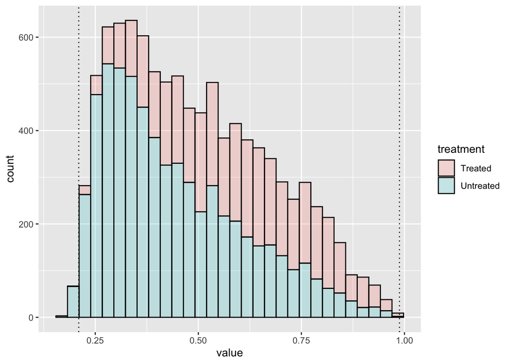

```r
df  <- read.dta("sipp1991.dta")
Y <- df[,"net_tfa"]
D <- df[,"e401"]
X.L <- cbind(df[,"age"], df[,"inc"], df[,"educ"], df[,"fsize"], df[,"marr"], df[,"twoearn"], df[,"db"], df[,"pira"], df[,"hown"])

X <- scale(X.L,center=TRUE,scale=TRUE) #Centers and scales X
  #Impose common support. More discussion in Appendix B.
  p.1 <- multinom(D~X-1, trace=FALSE)$fitted.values
  indexes.to.drop <- which(p.1 < min(p.1[D==1]) | max(p.1[D==1]) < p.1)

probs = data.frame("treatment" = append(rep("Treated",length(p.1[D==1])),rep("Untreated",length(p.1[D==0]))),"value" = append(p.1[D==1],p.1[D==0]))

ggplot(probs,aes(x = value, fill = treatment))+
  geom_histogram(alpha = 0.2, col = "black")+
  geom_vline(xintercept = min(p.1[D==1]),linetype = "dotted")+
  geom_vline(xintercept = max(p.1[D==1]),linetype = "dotted")
```

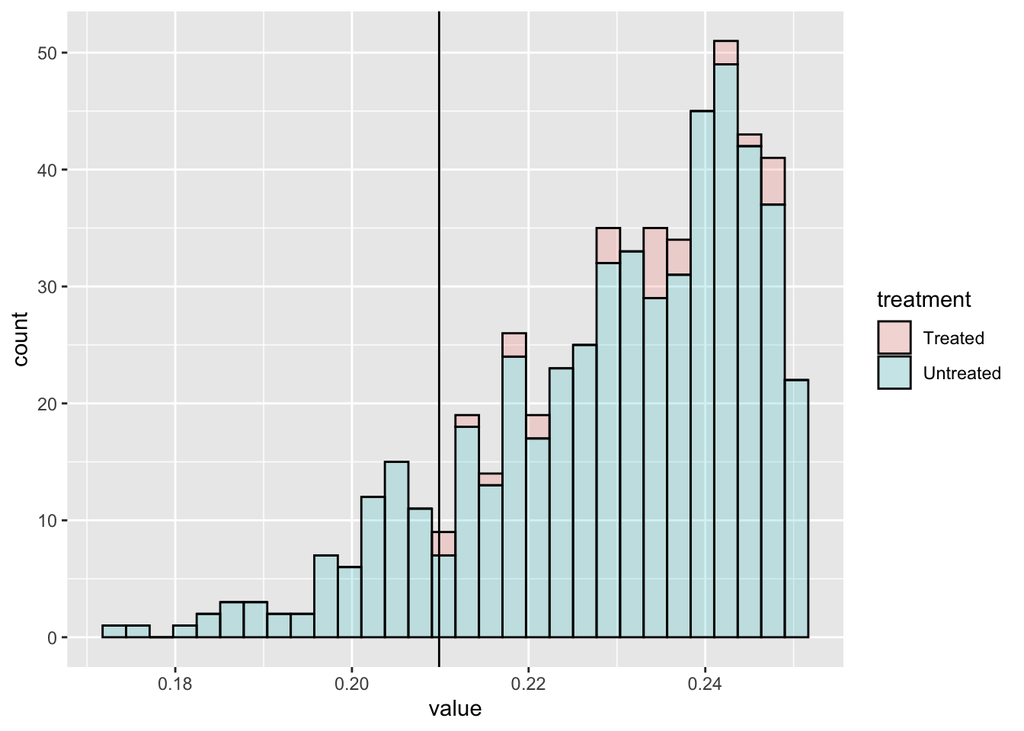

```r
probs %>%
  filter(value<=0.25)%>%
  ggplot(aes(x = value, fill = treatment))+
  geom_histogram(alpha = 0.2, col = "black")+
  geom_vline(xintercept = min(p.1[D==1]))
```

## Appendix C: Calculating Alpha

Alpha--known as the Riesz representer--can be calculated in two different ways. The first way is using propensity scores as follows:

1. Learn
   $$\pi(X) = P(D=1|X)$$
   . This is typically done by fitting a logistic curve to your data
2. Calculate the Riesz representer from $\pi$ as
   $$\alpha_0(D,X) = \frac{D}{\pi(X)}+\frac{1-D}{1-\pi(X)}$$

However, this suffers from several practical issues. For instance, since the propensity scores are learned on a logistic curve, there are often values very close to 0 or very close to 1. These values then result in large values in the denominator of alpha, making this calculation unstable. Fortunately, there is a more direct way to calculate the Riesz representer that is used in this guide. This approach leverages a powerful mathematical fact about the Riesz representer: $\mathbb{E}[m(W,\gamma)] = \mathbb{E}[\alpha_0(W)\gamma(W)]$. We can then try to find an $\alpha$ that minimizes the loss function
$$L = \mathbb{E}[\alpha_0(W)-\alpha(W)]^2$$
.

We can then use the above fact to derive the following:
$$L(\alpha) = C-2\mathbb{E}[m(W,\alpha)]+\mathbb{E}[\alpha(W)]^2$$
.

Now that we've solved the problem of estimating $\alpha$, we can expand on our work by using differnt loss functions. In the above example, we used a squared loss. However, we might want to add a regulization term, and have a loss function like
$$L(\rho) = C-2\rho^{'}\hat{M}+\rho^{'}\hat{G}\rho+2\lambda||\rho||_1$$
, which we could then optimize. Thus, using this approach we have a lot of options for how we want to measure $\alpha$ that rely on optimizing relatively simple loss functions